# rstatix

### Effect size for t-test

Cohen’s d measure of effect size allows us to compute the effect size for a given t-test.

This is calculated as the difference between mean minus mu divided by the standard deviation.

Effect Sizes:

- 0.2: small effect
- 0.5: moderate effect
- 0.8: large effect

Cohen’s d Formula

d = (m - μ) / s

d = (mA−mB) / SDpooled

```r
penguin_clean <- penguins %>%
  drop_na()

#t-test effect size for one sample
effect_one <- penguins %>%
  cohens_d(body_mass_g ~ 1, mu = 3775)
effect_one
```

```
## # A tibble: 1 x 6
##   .y.         group1 group2     effsize     n magnitude
## * <chr>       <chr>  <chr>        <dbl> <int> <ord>
## 1 body_mass_g 1      null model   0.532   344 moderate
```

```r
#T-test effect size for two independent samples
effect_two <-penguin_clean %>%
  cohens_d(bill_length_mm ~ sex, var.equal = TRUE)
effect_two
```

```
## # A tibble: 1 x 7
##   .y.            group1 group2 effsize    n1    n2 magnitude
## * <chr>          <chr>  <chr>    <dbl> <int> <int> <ord>
## 1 bill_length_mm female male    -0.731   165   168 moderate
```

## ANOVA test

ANOVA testing (Analysis of Variance) is used to compare means between two or more independent groups. If there is an experiment that has one factor, the ANOVA test is called a **one-way ANOVA**. If there are two factors, then it is called a **two-way ANOVA**. A one-way ANOVA is a common from of testing using one grouping variable.

This package has many different ANOVA tests that can be piped into the code:

- Independent measures ANOVA
- Repeated measures ANOVA
- Mixed ANOVA
- ANCOVA: Analysis of Covariance

The table consists of several different columns:

- DFn: degrees of freedom in the numerator
- DFd: degrees of freedom in the denominator
- F: F distribution (F-test)
- p: p-value
- p< 0.05: astrisks if the p-value is less than 0.05
- ges: generalized effect size

On top of the different ANOVA tests, there are other post-hoc tests included in the package that can be a better fit for different types of data.

```r
#for ANOVA testing, it is best to not have any NAs in the data
penguins_clean <- penguins %>%
  drop_na()

#one-way ANOVA
#variable: bill length
#can get anova table in the console by using get_anova_table
#objecting the test helps to open the anova table in a new tab
one_way_pens <-penguins_clean %>%
  anova_test(year ~ bill_length_mm)
get_anova_table(one_way_pens, correction = "none")
```

```
## ANOVA Table (type II tests)
##
##           Effect DFn DFd     F     p p<.05   ges
## 1 bill_length_mm   1 331 0.353 0.553       0.001
```

```r
#correction is used only in repeated measures and it refers to the degrees of freedom reported for the within-subject factors


#grouped one-way ANOVA
#grouping by species
group_anova <- penguins_clean %>%
  group_by(species) %>%
  anova_test(year ~ bill_length_mm)
get_anova_table(group_anova)
```

```
## # A tibble: 3 x 8
##   species   Effect           DFn   DFd     F     p `p<.05`      ges
## * <fct>     <chr>          <dbl> <dbl> <dbl> <dbl> <chr>      <dbl>
## 1 Adelie    bill_length_mm     1   144 0.016 0.899 ""      0.000111
## 2 Chinstrap bill_length_mm     1    66 0.118 0.732 ""      0.002
## 3 Gentoo    bill_length_mm     1   117 5.11  0.026 "*"     0.042
```

```r
#two-way ANOVA
#two variables: bill length and depth
two_way_pens <- penguins_clean %>%
  anova_test(year ~ bill_length_mm*bill_depth_mm)
get_anova_table(two_way_pens, correction = "none")
```

```
## ANOVA Table (type II tests)
##
##                         Effect DFn DFd     F     p p<.05      ges
## 1               bill_length_mm   1 329 0.163 0.686       0.000496
## 2                bill_depth_mm   1 329 0.578 0.448       0.002000
## 3 bill_length_mm:bill_depth_mm   1 329 0.458 0.499       0.001000
```

```r
#grouped two-way ANOVA
group_twopens <- penguins_clean %>%
  group_by(species) %>%
  anova_test(year ~ bill_length_mm*bill_depth_mm)
get_anova_table(group_twopens)
```

```
## # A tibble: 9 x 8
##   species   Effect                        DFn   DFd      F     p `p<.05`     ges
## * <fct>     <chr>                       <dbl> <dbl>  <dbl> <dbl> <chr>     <dbl>
## 1 Adelie    bill_length_mm                  1   142  1.83  0.179 ""      1.3 e-2
## 2 Adelie    bill_depth_mm                   1   142 10.2   0.002 "*"     6.7 e-2
## 3 Adelie    bill_length_mm:bill_depth_~     1   142  0.056 0.813 ""      3.94e-4
## 4 Chinstrap bill_length_mm                  1    64  0.74  0.393 ""      1.1 e-2
## 5 Chinstrap bill_depth_mm                   1    64  0.848 0.361 ""      1.3 e-2
## 6 Chinstrap bill_length_mm:bill_depth_~     1    64  0.137 0.712 ""      2   e-3
## 7 Gentoo    bill_length_mm                  1   115  0.444 0.506 ""      4   e-3
## 8 Gentoo    bill_depth_mm                   1   115  2.57  0.112 ""      2.2 e-2
## 9 Gentoo    bill_length_mm:bill_depth_~     1   115  0.143 0.706 ""      1   e-3
```

## Correlation Test

Correlation tests can be used to compare the association between two or more variables.

There are different methods that can be used to compare associations:

- Pearson’s correlation: a linear relationship/correlation between the variables (parametric)
- Kendall tau: measures the correlation between variables when ranked (non-parametric)
- Spearmann rho: measures the correlation between variables when ranked (non-parametric)

Values range between -1 and 1. Negative values (-1 to 0) mean that there is a negative association between the variables. Positive values (0 to 1) mean that there is positive association between the variables. 0 means there is no association between the variables.

```r
#again using a dataset where we dropped the NAs -> penguins_clean

corpens <-penguins_clean %>%
  cor_test(bill_length_mm, method = "pearson")
view(corpens)

#can group by species
corgroup <- penguins_clean %>%
  group_by(species) %>%
  cor_test(bill_length_mm, bill_depth_mm, method = "pearson")
view(corgroup)
```

### Correlation matrix

We can also create a correlation matrix with the package!

```r
data <- penguins_clean %>%
  select(species, bill_length_mm, bill_depth_mm, flipper_length_mm, body_mass_g)
view(data)

cordata <- data %>% cor_test(body_mass_g, method = "pearson")
cordata
```

```
## # A tibble: 3 x 8
##   var1        var2             cor statistic         p conf.low conf.high method
##   <chr>       <chr>          <dbl>     <dbl>     <dbl>    <dbl>     <dbl> <chr>
## 1 body_mass_g bill_length_mm  0.59     13.3  1.54e- 32    0.515     0.655 Pears~
## 2 body_mass_g bill_depth_mm  -0.47     -9.74 7.02e- 20   -0.552    -0.384 Pears~
## 3 body_mass_g flipper_lengt~  0.87     32.6  3.13e-105    0.845     0.896 Pears~
```

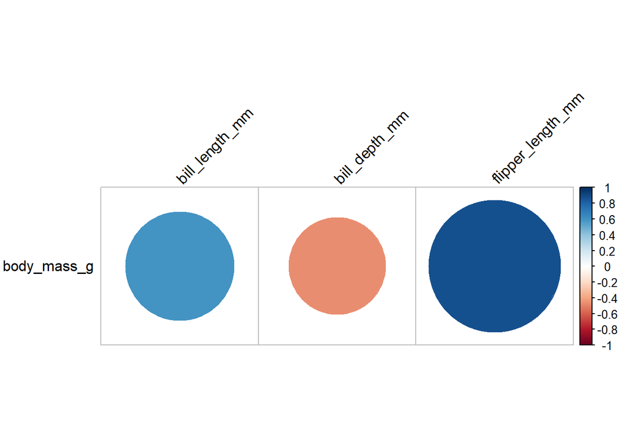

```r
#creating a correlation matrix
cormatpens <- data %>%
  cor_mat(body_mass_g, method = "pearson") %>%
  cor_plot()
```

```r
view(cormatpens)
```